# **crestr** A R package to perform probabilistic palaeoclimate reconstructions from fossil bio-proxies

The goal of crestr is to produce probabilistic reconstructions of past climate change from fossil assemblage data. The approach is based on the estimation of conditional responses of studies bio-proxy studied to climate parameters using probability density functions (*PDFs*; see [Chevalier *et al.* (2014)](http://www.doi.org/10.5194/cp-10-2081-2014) and [Chevalier (2019)](http://www.doi.org/10.1016/j.gloplacha.2019.01.016)). The theory underpinning this package is explained in section [*A bit of theory*](https://mchevalier2.github.io/crestr/articles/theory.html) and is illustrated with an application based on pseudo-data in section [*Get Started*](https://mchevalier2.github.io/crestr/articles/get-started.html). The different vignettes present different aspects of the structure of the package and the data it contains, along with applications based on real data.

> *NOTE:* If you notice any bug, or if you would like to see some specific functions implemented, you can contact me at chevalier.manuel@gmail.com.

## Installation

You can install the development version from [GitHub](https://github.com/) with:

```r
if(!require(devtools)) install.packages("devtools")
devtools::install_github("mchevalier2/crestr")
```

## CREST in the scientific litterature

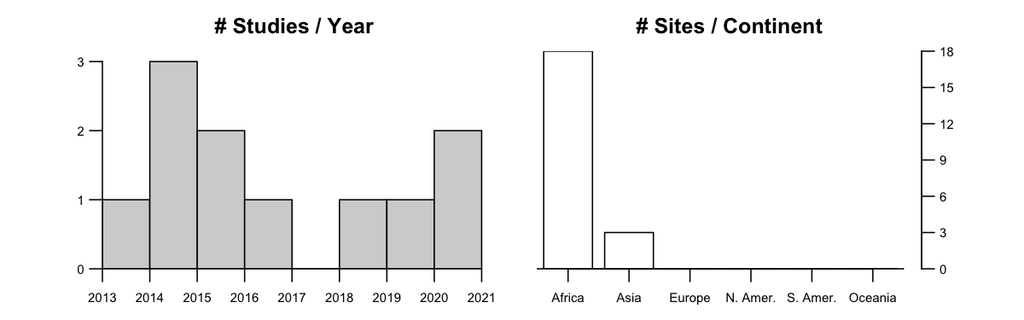

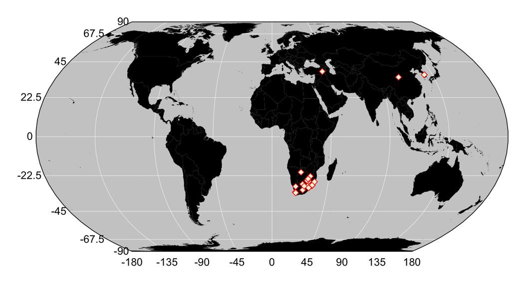

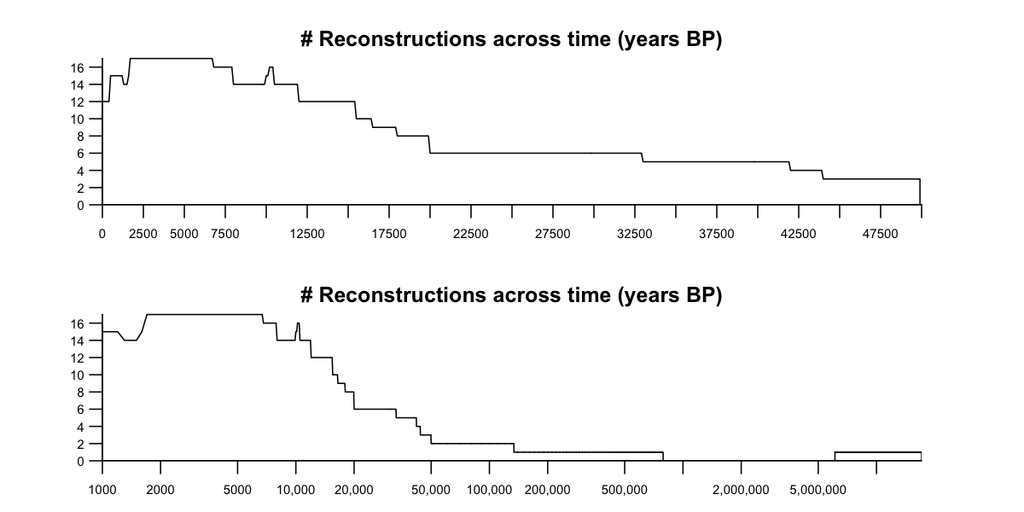

[figure not shown]

Last update: 23/08/2021

## Example applications

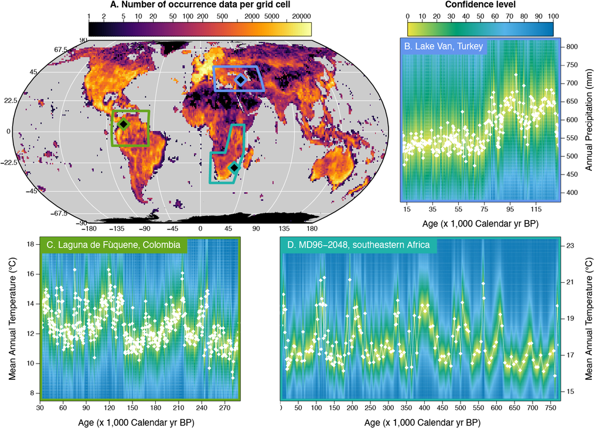

*(A) density of presence records available in my calibration dataset upscaled at a 1° resolution. The diamonds represent the location of pollen records used to generate the reconstructions presented in B-D and the coloured boxes represent the extent of their respective calibration zones. (B) Annual precipitation reconstructions from Lake Van, Turkey ([Chevalier, 2019](http://www.doi.org/10.1016/j.gloplacha.2019.01.016)), (C) Mean annual temperature reconstruction from Laguna de Fùquene, Colombia (unpublished) and (D) Mean Annual temperature reconstruction from marine core MD96-2048 ([Chevalier et al., 2021](http://www.doi.org/10.1130/G47841.1)).*

## References

- Chevalier, M., Cheddadi, R., Chase, B.M., 2014. CREST (Climate REconstruction SofTware): a probability density function (PDF)-based quantitative climate reconstruction method. *Clim. Past* 10, 2081–2098. 10.5194/cp-10-2081-2014
- Chevalier, M., 2019. Enabling possibilities to quantify past climate from fossil assemblages at a global scale. *Glob. Planet. Change* 175, 27–35. 10.1016/j.gloplacha.2019.01.016
- Chevalier, M., Chase, B.M., Quick, L.J., Dupont, L.M. and Johnson, T.C., 2021. Temperature change in subtropical southeastern Africa during the past 790,000 yr. *Geology* 49, 71–75. 10.1130/G47841.1